# Master TIDE - Conférences Python 2020

Francis Wolinski

© 2020 Yotta Conseil

## Cartographies avec `plotly`

```python
# imports
import os

import numpy as np
import pandas as pd
import matplotlib as mpl
import matplotlib.pyplot as plt
import seaborn as sns
from matplotlib import cm
%matplotlib inline

# display options
pd.set_option("display.max_rows", 20)
```

### Dataset

```python
# load countries
if os.path.exists('GeoNames.htm') :
    var = pd.read_html('GeoNames.htm',
                       header=0,
                       keep_default_na=False,
                       encoding='latin-1')
else:
    var = pd.read_html('https://www.geonames.org/countries/',
                       header=0,
                       keep_default_na=False,
                       encoding='latin-1')
df = var[1]
df.shape
```

```
(252, 9)
```

```python
df.head()
```

|  | ISO-3166alpha2 | ISO-3166alpha3 | ISO-3166numeric | fips | Country | Capital | Area in km² | Population | Continent |
| --- | --- | --- | --- | --- | --- | --- | --- | --- | --- |
| 0 | AD | AND | 20 | AN | Andorra | Andorra la Vella | 468.0 | 84000 | EU |
| 1 | AE | ARE | 784 | AE | United Arab Emirates | Abu Dhabi | 82880.0 | 4975593 | AS |
| 2 | AF | AFG | 4 | AF | Afghanistan | Kabul | 647500.0 | 29121286 | AS |
| 3 | AG | ATG | 28 | AC | Antigua and Barbuda | St. John's | 443.0 | 86754 | NA |
| 4 | AI | AIA | 660 | AV | Anguilla | The Valley | 102.0 | 13254 | NA |

## Cartes avec `plotly`

Installation de `plotly` et de `colorlover` avec `conda`:

`plotly` est une librairie graphique développée par une société canadienne. An interactive, browser-based graphing library for Python. Voir aussi `dash` un framework pour produire des applications web en Python basé sur `flask`.

`colorlover` est une librairie d'échelle de couleurs utilisée.

Installation, ouvrir un terminal dans le dossier `anaconda3/condabin` :

- PC: `.\conda install -c plotly plotly`
- Mac: `./conda install -c plotly plotly`
- PC: `.\conda install -c conda-forge colorlover`
- Mac: `./conda install -c conda-forge colorlover`

```python
# imports
from plotly.offline import iplot, init_notebook_mode
import colorlover as cl

# init
init_notebook_mode(connected=True)
```

Avec `plotly` il est possible de définir des graphiques de manière déclarative, en définissant une structure de données et avec peu de lignes de code.

#### Carte avec `choropleth` (polygones)

```python
data = [{
        'type': 'choropleth',
        'locations': df['ISO-3166alpha3'],
        'z': df['Population'],
        'text': df['Country'],
        'colorscale': list(zip(np.linspace(0, 1, 9), cl.scales['9']['seq']['Reds'])),
        'autocolorscale': False,
        'reversescale': False,
        'marker': {
            'line': {
                'color': 'rgb(180,180,180)',
                'width': 0.5
            }},
        'colorbar':
            {'autotick': False,
            'title': 'Population'},
        }]

layout = {
    'title': '<br>Source:\
            <a href="https://www.geonames.org/countries/">\
            geonames</a>',
    'geo': {
        'showcountries': True,
        'showframe': False,
        'showcoastlines': False,
        'projection': {
            'type': 'natural earth'
        }
    }
}


fig = {'data': data, 'layout': layout}
iplot(fig, validate=False, filename='d3-world-map')
```

[interactive chart not shown]

**Exercise 1**

- Ajouter une colonne 'Densité' au 'DataFrame'.
- Afficher la densité en utilisant la colormap 'Blues'.
- Limiter les valeurs de la densité pour obtenir les nuances de couleur.
- Choisir une projection parmi les suivantes : 'equirectangular', 'mercator', 'orthographic', 'natural earth', 'kavrayskiy7', 'miller', 'robinson', 'eckert4', 'azimuthal equal area', 'azimuthal equidistant', 'conic equal area', 'conic conformal', 'conic equidistant', 'gnomonic', 'stereographic', 'mollweide', 'hammer', 'transverse mercator'

```python
df.info()
```

```
<class 'pandas.core.frame.DataFrame'>
RangeIndex: 252 entries, 0 to 251
Data columns (total 9 columns):
ISO-3166alpha2     252 non-null object
ISO-3166alpha3     252 non-null object
ISO-3166numeric    252 non-null int64
fips               252 non-null object
Country            252 non-null object
Capital            252 non-null object
Area in km²        252 non-null float64
Population         252 non-null int64
Continent          252 non-null object
dtypes: float64(1), int64(2), object(6)
memory usage: 17.8+ KB
```

```python
df['Densité'] = df['Population'] / df['Area in km²']
df['Densité'] = df['Densité'].clip(None, 500)
```

```python
df.head()
```

|  | ISO-3166alpha2 | ISO-3166alpha3 | ISO-3166numeric | fips | Country | Capital | Area in km² | Population | Continent | Densité |
| --- | --- | --- | --- | --- | --- | --- | --- | --- | --- | --- |
| 0 | AD | AND | 20 | AN | Andorra | Andorra la Vella | 468.0 | 84000 | EU | 179.487179 |
| 1 | AE | ARE | 784 | AE | United Arab Emirates | Abu Dhabi | 82880.0 | 4975593 | AS | 60.033699 |
| 2 | AF | AFG | 4 | AF | Afghanistan | Kabul | 647500.0 | 29121286 | AS | 44.974959 |
| 3 | AG | ATG | 28 | AC | Antigua and Barbuda | St. John's | 443.0 | 86754 | NA | 195.832957 |
| 4 | AI | AIA | 660 | AV | Anguilla | The Valley | 102.0 | 13254 | NA | 129.941176 |

```python
pd.Series.clip?
```

```python
data = [{
        'type': 'choropleth',
        'locations': df['ISO-3166alpha3'],
        'z': df['Densité'],
        'text': df['Country'],
        'colorscale': list(zip(np.linspace(0, 1, 9), cl.scales['9']['seq']['Blues'])),
        'autocolorscale': False,
        'reversescale': False,
        'marker': {
            'line': {
                'color': 'rgb(180,180,180)',
                'width': 0.5
            }},
        'colorbar':
            {'autotick': False,
            'title': 'Densité'},
        }]

layout = {
    'title': '<br>Source:\
            <a href="https://www.geonames.org/countries/">\
            geonames</a>',
    'geo': {
        'showcountries': True,
        'showframe': False,
        'showcoastlines': False,
        'projection': {
            'type': 'azimuthal equidistant'
        }
    }
}


fig = {'data': data, 'layout': layout}
iplot(fig, validate=False, filename='d3-world-map')
```

[interactive chart not shown]

[figure not shown]

```python
sns.boxplot(df['Densité']);
```

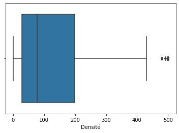

```python
sns.boxplot(df['Densité']);
```

#### Carte avec `scattergeo` (points)

```python
# cities5000.txt
villes = pd.read_csv('cities5000.txt',
                   sep='\t',
                   header=None,
                   names=['geonameid', 'name', 'asciiname', 'alternatenames', 'latitude', 'longitude', 'feature class', 'feature code', 'country code', 'cc2', 'admin1 code', 'admin2 code', 'admin3 code', 'admin4 code', 'population', 'elevation', 'dem', 'timezone', 'modification date'],
                   dtype={'admin1 code': str, 'admin2 code': str, 'admin3 code': str, 'admin4 code': str},
                   keep_default_na=False,
                   usecols=[2, 4, 5, 7, 8, 14])
villes.columns = ['asciiname', 'latitude', 'longitude', 'type', 'iso_2', 'population']
capitales = villes.loc[villes['type'] == 'PPLC']
capitales.head()
```

|  | asciiname | latitude | longitude | type | iso_2 | population |
| --- | --- | --- | --- | --- | --- | --- |
| 6 | Andorra la Vella | 42.50779 | 1.52109 | PPLC | AD | 20430 |
| 21 | Abu Dhabi | 24.45118 | 54.39696 | PPLC | AE | 603492 |
| 81 | Kabul | 34.52813 | 69.17233 | PPLC | AF | 3043532 |
| 119 | Saint John's | 17.12096 | -61.84329 | PPLC | AG | 24226 |
| 126 | The Valley | 18.21704 | -63.05783 | PPLC | AI | 2035 |

```python
# jointure pour obtenir latitude et longitude
df = pd.merge(df, capitales, left_on='ISO-3166alpha2', right_on='iso_2', how='left')
df.head()
```

|  | ISO-3166alpha2 | ISO-3166alpha3 | ISO-3166numeric | fips | Country | Capital | Area in km² | Population | Continent | Densité | asciiname | latitude | longitude | type | iso_2 | population |
| --- | --- | --- | --- | --- | --- | --- | --- | --- | --- | --- | --- | --- | --- | --- | --- | --- |
| 0 | AD | AND | 20 | AN | Andorra | Andorra la Vella | 468.0 | 84000 | EU | 179.487179 | Andorra la Vella | 42.50779 | 1.52109 | PPLC | AD | 20430.0 |
| 1 | AE | ARE | 784 | AE | United Arab Emirates | Abu Dhabi | 82880.0 | 4975593 | AS | 60.033699 | Abu Dhabi | 24.45118 | 54.39696 | PPLC | AE | 603492.0 |
| 2 | AF | AFG | 4 | AF | Afghanistan | Kabul | 647500.0 | 29121286 | AS | 44.974959 | Kabul | 34.52813 | 69.17233 | PPLC | AF | 3043532.0 |
| 3 | AG | ATG | 28 | AC | Antigua and Barbuda | St. John's | 443.0 | 86754 | NA | 195.832957 | Saint John's | 17.12096 | -61.84329 | PPLC | AG | 24226.0 |
| 4 | AI | AIA | 660 | AV | Anguilla | The Valley | 102.0 | 13254 | NA | 129.941176 | The Valley | 18.21704 | -63.05783 | PPLC | AI | 2035.0 |

```python
# affichage des pays où la densité est supérieure à 200 h/km²
df['Densité'] = df['Population'] / df['Area in km²']
df2 = df.loc[df['Densité']>200]

data = [{
        'type': 'scattergeo',
        'locations': df2['ISO-3166alpha3'],
        'text': df2['Country'] + ' (' + df2['Densité'].astype(int).astype(str) + ')',
        'z': df2['Densité'],
        'lon': df2['longitude'].values,
        'lat': df2['latitude'].values,
        'mode': 'markers',
        'marker': {
            'symbol': 'star',
            'color': 'navy',
            'size': 8
            },
        }]

layout = {
    'title': '<br>Source:\
            <a href="https://www.geonames.org/countries/">\
            geonames</a>',
    'geo': {
        'countrycolor': 'white',
        'showland': True,
        'landcolor': 'lightgrey',
        'showcountries': True,
        'showframe': False,
        'showcoastlines': False,
        'projection': {
            'type': 'natural earth'
        }
    }
}

fig = {'data': data, 'layout': layout}
iplot(fig, validate=False, filename='d3-world-map')
```

[interactive chart not shown]

Il est possible de combiner des cartes `choropleth` et `scattergeo` en partionnant les pays et en insérant autant de dictionnaires dans la liste data.

**Pour plus d'information**

- https://plot.ly/

### Géocodage avec le module `geopy` et cartes avec le module `ipyleaflet` (démo)

`geopy` permet de géocoder des adresses physiques.

`ipyleaflet` fournit des cartes interactives pour Jupyter basé sur la librairie javascript leaflet.js et OpenStreetMap.

Installation, ouvrir un terminal dans le dossier `anaconda3/condabin` :

- PC: `.\conda install -c conda-forge geopy`
- Mac: `./conda install -c conda-forge geopy`
- PC: `.\conda install -c conda-forge ipyleaflet`
- Mac: `./conda install -c conda-forge ipyleaflet`
- PC: `.\jupyter nbextension enable --py --sys-prefix ipyleaflet`
- Mac: `./jupyter nbextension enable --py --sys-prefix ipyleaflet`

### Géocodage

Prior to display a position on a map, we will use the `geopy` module to get latitude and longitude from a real world address:

```
90 rue de Tolbiac, 75013 Paris
```

Geocoding is the process of taking input text, such as an address or the name of a place, and returning a latitude/longitude location on the Earth's surface for that place.

The `geopy` library provides an interface to a list of geolocation service you might use, such as Google Maps, Bing Maps, or Nominatim.

```python
from geopy import geocoders
```

```python
geocoders.GoogleV3?
```

```python
# si erreur Python ssl.SSLError
#import ssl
#import certifi
#ctx = ssl.create_default_context(cafile=certifi.where())
#import geopy
#geopy.geocoders.options.default_ssl_context = ctx

from geopy.geocoders import Nominatim

geolocator = Nominatim(user_agent='TIDE', timeout=15)
location = geolocator.geocode('90 rue de Tolbiac 75013 Paris')
location.raw
```

[output not shown]

[output cut: 58 more lines]

[output not shown]

```python
# latitude et longitude
lat, lon = location.raw['lat'], location.raw['lon']
lat, lon
```

**Pour plus d'information**

- https://geopy.readthedocs.io/en/stable/index.html

### Carte standard

```python
lat, lon = 48.8272513, 2.3648174
```

```python
# démo
from ipyleaflet import Map

# carte autour de 48.8272513, 2.3648174
m = Map(center=(lat, lon), zoom=18)
m
```

### Carte satellite

```python
# carte satellite
from datetime import datetime, timedelta
from ipyleaflet import basemaps, basemap_to_tiles

# carte satellite de la veille
# NASA's Global Imagery Browse Services
yesterday = datetime.now() - timedelta(days=1)
nasa = basemap_to_tiles(basemaps.NASAGIBS.ModisTerraTrueColorCR, yesterday.strftime('%Y-%m-%d'))
m = Map(layers=(nasa, ), center=(lat, lon), zoom=4)

m
```

```python
dir(basemaps.Stamen)
```

```
['Terrain', 'Toner', 'Watercolor']
```

### Autre carte

```python
# autre carte avec marqueurs

from ipyleaflet import Marker, LayerGroup

watercolor = basemap_to_tiles(basemaps.Stamen.Watercolor)
m = Map(layers=(watercolor, ), center=(50, 50), zoom=1)

# marqueurs pour les villes dont la population >= 3M
villes = villes.loc[villes['population'] >= 3e6]
layers = []
for i, row in villes.iterrows():
    marker = Marker(location=(row['latitude'], row['longitude']),
                    draggable=False,
                    title=row['asciiname'])
    layers.append(marker)
layer_group = LayerGroup(layers=layers)
m.add_layer(layer_group)

m
```

**Pour plus d'information**

- https://ipyleaflet.readthedocs.io/en/latest/index.html